# Task1

2022-09-22

## R Markdown

First off, we load the data points from data4led. This was downloaded beforehand from devtools::install_github(“byuidatascience/data4led”). The function bulb is created, which takes the data points from one bulb from a unique seed from the original data library. We take this data and unique seed to calculate the intensity (y-axis) and time (x-axis) for that one led at 44 separate points in time with varying intensity.

The head function gives us six points at different hours and intensity.

The par function affects the margins of the plot from bottom, left, top, and right. The plot function has filters in its function. Ylim filters the intensity to only show between 98% and 102%. The pch affects the font of the data points. Main changes the title of the plot, the xlab and ylab change the horizontal and vertical titles respectively.

```r
library(data4led)

bulb <- led_bulb(1,seed = 6154)

x <- bulb$hours
y <- bulb$percent_intensity

head(bulb)
```

```
##       id hours intensity normalized_intensity percent_intensity
## 4709 108     0  799.3000            1.0000000         100.00000
## 4710 108    26  797.0231            0.9971514          99.71514
## 4711 108    91  805.8683            1.0082176         100.82176
## 4712 108   192  807.9450            1.0108157         101.08157
## 4713 108   293  800.7074            1.0017608         100.17608
## 4714 108   403  801.0067            1.0021353         100.21353
```

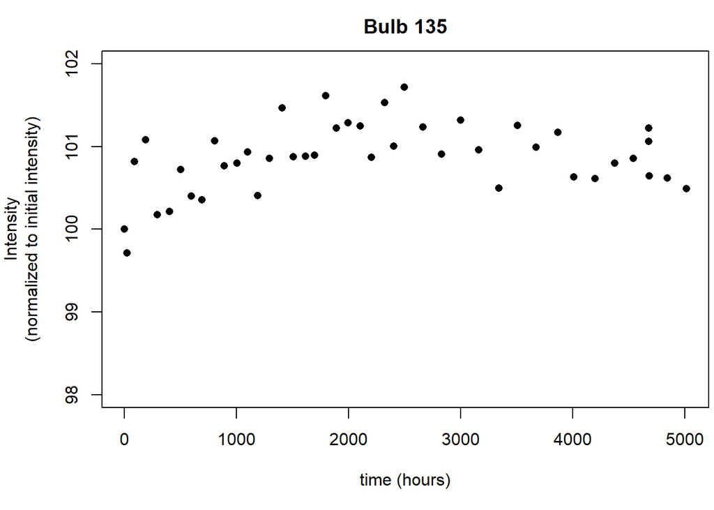

```r
par(mar=c(5,5,2.5,0.25))
plot(x,y,ylim=c(98,102),pch=16,main='Bulb 135',xlab="time (hours)",ylab='Intensity\n(normalized to initial intensity)')
```